# BIOS 545 - 2019 - Lecture 8: Simulation Part I

Ziyi Li (ziyi.li@emory.edu)

#### Advantage of doing simulation study in R:

R allows researchers to generate and manipulate their data with much more flexibility than many other programs, and contains packages to run a multitude of statistical analyses of interest to researchers in a variety of domains.

## Content

- **Useful functions for simulation**
- **Setting Seed**
- **Example: simulation using a linear model**

## 1. Useful functions for simulation

#### Generate normal random variables

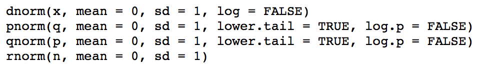

```r
# Generate 10 normal distribution variables
rnorm(10)
```

```
##  [1]  0.22425779 -0.65168590 -0.02149744  0.89522511  1.10270310
##  [6] -1.16953307  1.11945482 -1.22982583 -0.07935609 -0.54812344
```

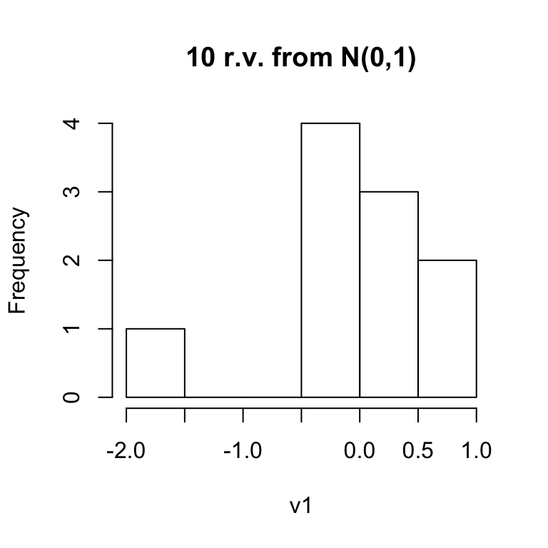

```r
# Let's visualize our generated random numbers
v1 = rnorm(10)
hist(v1, main = "10 r.v. from N(0,1)")
```

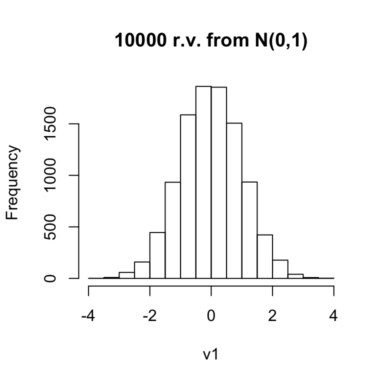

```r
# More random numbers will make the plot more "normal-like"
v1 = rnorm(10000)
hist(v1, main = "10000 r.v. from N(0,1)")
```

We can change the mean and sd of normal distribution

```r
# Change distribution mean and sd
rnorm(10, mean = 2, sd = 0.5)
```

```
##  [1] 2.363334 2.891566 1.681129 1.392636 1.286330 2.107473 1.821238
##  [8] 1.907861 2.088317 2.612859
```

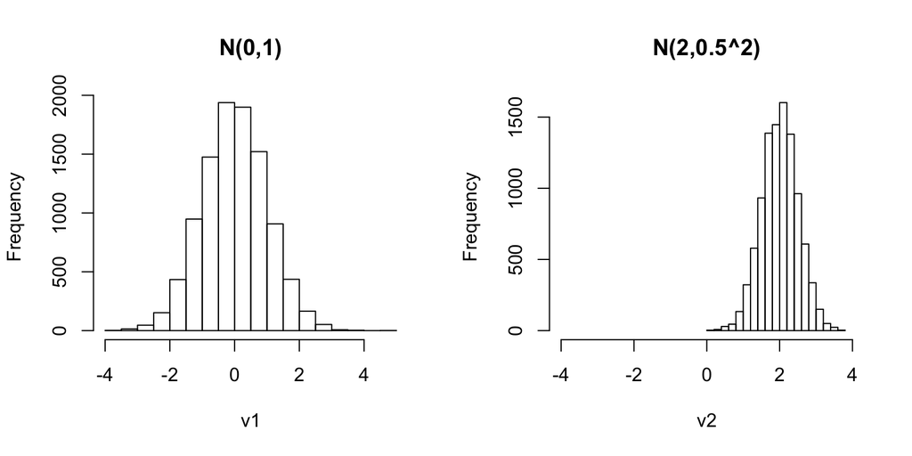

```r
par(mfrow = c(1,2))
v1 = rnorm(10000)
hist(v1, main = "N(0,1)")

v2 = rnorm(10000, mean = 2, sd = 0.5)
hist(v2, main = "N(2,0.5^2)", xlim = c(-4,4))
```

- `dnorm()` : Density function of Normal distribution (p.d.f: Probability density function)
- `pnorm()` : Probability function of Normal distribution (c.d.f: Cumulative density function)
  $$pnorm(q) = \phi(q)$$
- `qnorm()` : Quantile function of Normal distribution (inverse of c.d.f)
  $$qnorm(q) = \phi^{-1}(q)$$

```r
dnorm(0)
```

```
## [1] 0.3989423
```

```r
pnorm(0)
```

```
## [1] 0.5
```

```r
qnorm(0.5)
```

```
## [1] 0
```

```r
qnorm(0.5, mean = 2, sd = 0.5)
```

```
## [1] 2
```

#### Most (if not all) available distributions available in R:

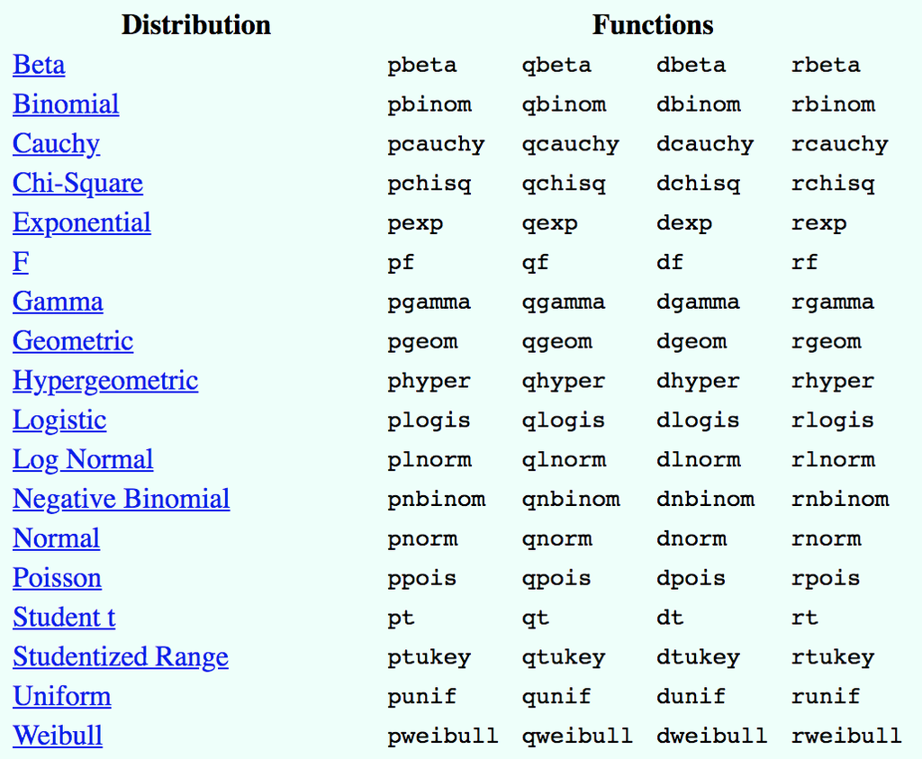

<ref: http://www.stat.umn.edu/geyer/old/5101/rlook.html>

```r
# random number from poisson distribution
rpois(5, lambda=0.2)
```

```
## [1] 0 0 0 0 0
```

```r
# Cumulative distribution
ppois(2, 2)  ## Pr(x <= 2)
```

```
## [1] 0.6766764
```

```r
ppois(4, 2)  ## Pr(x <= 4)
```

```
## [1] 0.947347
```

```r
ppois(6, 2)  ## Pr(x <= 6)
```

```
## [1] 0.9954662
```

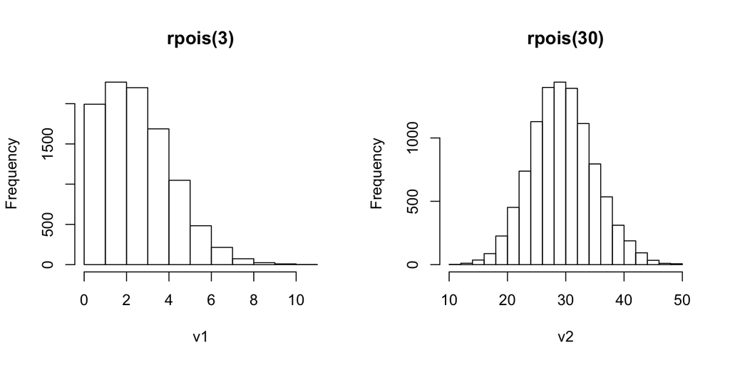

```r
# poisson distribution with different parameters

par(mfrow = c(1,2))
v1 = rpois(10000, lambda = 3)
hist(v1, main = "rpois(3)")

v2 = rpois(10000, lambda = 30)
hist(v2, main = "rpois(30)")
```

### Another useful function: `sample()`

Draw random samples from a given vector with or without replacement.

```r
x = 1:10

sample(x, size = 4, replace = FALSE)
```

```
## [1] 5 7 4 2
```

```r
sample(x, size = 4, replace = TRUE)
```

```
## [1] 5 4 1 8
```

```r
sample(x, size = 14, replace = TRUE)
```

```
##  [1]  9  5  1  1 10  1  7 10  4  8  7  7  6  1
```

## 2. Setting seed

Setting the random number seed with `set.seed` ensures reproducibility.

```r
set.seed(1)

rnorm(10)
```

```
##  [1] -0.6264538  0.1836433 -0.8356286  1.5952808  0.3295078 -0.8204684
##  [7]  0.4874291  0.7383247  0.5757814 -0.3053884
```

```r
rnorm(10)
```

```
##  [1]  1.51178117  0.38984324 -0.62124058 -2.21469989  1.12493092
##  [6] -0.04493361 -0.01619026  0.94383621  0.82122120  0.59390132
```

```r
set.seed(1)

rnorm(10)
```

```
##  [1] -0.6264538  0.1836433 -0.8356286  1.5952808  0.3295078 -0.8204684
##  [7]  0.4874291  0.7383247  0.5757814 -0.3053884
```

** Always set the random number seed when conducting a simulation! **

## 3. Simulations using a linear model

<ref: https://www.youtube.com/watch?v=tvv4IA8PEzw by Roger Peng.>

Suppose we want to simulate from the following linear model:

$$y = \beta_0 + \beta_1 x + \epsilon$$

Where $\epsilon \sim \mathcal{N}(0,3^2)$. Assume $x \sim \mathcal{N}(0,2^2)$, $\beta_0 = 0.6$ and $\beta_1 = 3$.

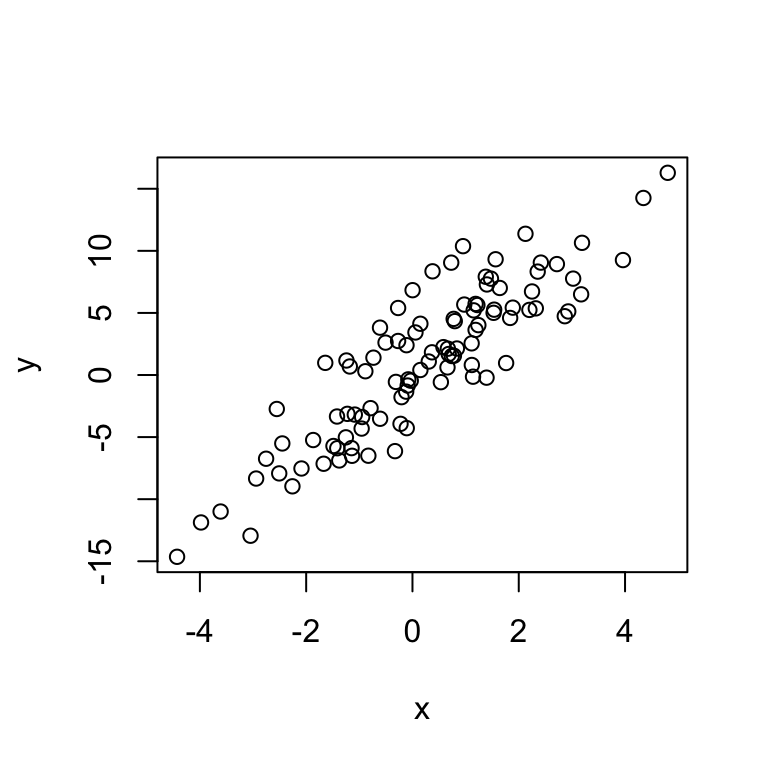

```r
set.seed(1)

x <- rnorm(100, 0, 2)
e <- rnorm(100, 0, 3)

y <- 0.6 + 3 * x + e

plot(x, y)
```

What if x is a binary variable that follows binomial distribution?

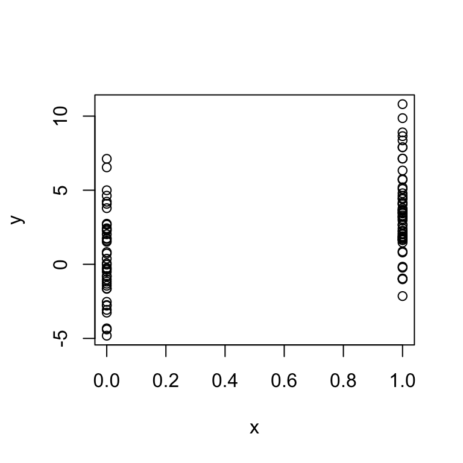

```r
set.seed(1)

x <- rbinom(100, 1, 0.6)
e <- rnorm(100, 0, 3)

y <- 0.6 + 3 * x + e

plot(x, y)
```

### Simulate from a Generalize Linear Model.

Suppose we want to simulate from a Poisson model:

$$y \sim Poisson(\mu)$$

$$log(\mu) = \beta_0 + \beta_1 x$$

where $x \sim \mathcal{N}(0,2^2)$, $\beta_0 = 0.6$ and $\beta_1 = 0.3$. We can use `rpois` function for this.

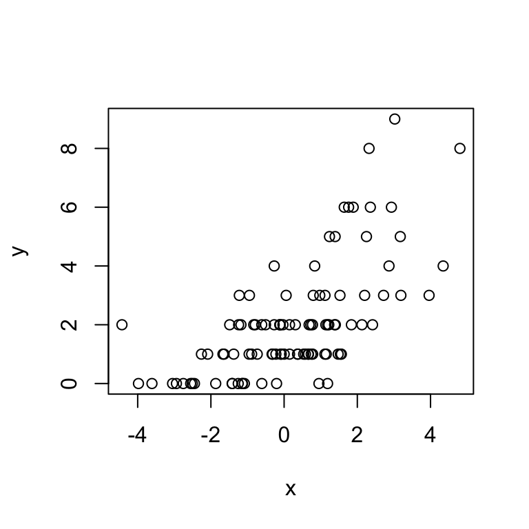

```r
set.seed(1)

x <- rnorm(100, 0, 2)
log_mu <- 0.6 + 0.3 * x

y <- rpois(100, exp(log_mu))

plot(x, y)
```